# dem_proj

chris

2023-04-21

```r
library(rio)
library(tidyverse)
library(ggpubr)
library(knitr)
library(kableExtra)
```

Import wave I and V from ADD Health.

Wave I: select participant ID, birth year, interview year, 19 CESD depression symptoms, and demographic variables (from contextual data).

Wave IV: select biological sex, and the 10 CESD items that were consistent with wave I (10/11)

Wave V: select if ever been diagnosed with depression and at what age diagnosed.

```r
wave1 <- import('data/wave1.rda')
wave11 <- import('data/wave1_1.rda')
wave4 <- import('data/wave4.rda')
wave5 <- import('data/wave5.rda')


dat1 <- wave1 %>%
  select(AID, H1GI1Y, IYEAR,
         H1FS1, H1FS2, H1FS3, H1FS4, H1FS5, H1FS6,
         H1FS7, H1FS8, H1FS9, H1FS10, H1FS11, H1FS12,
         H1FS13, H1FS14, H1FS15, H1FS16, H1FS17,
         H1FS18, H1FS19)

dat11 <- wave11 %>%
  select(AID,
         BST90P02, BST90P05, BST90P06, BST90P08,
         BST90P10, BST90P13, BST90P15, BST90P19,
         BST90P20, BST90P23, BST90P24)


dat4 <- wave4 %>%
  select(AID, BIO_SEX4,
         H4MH18:H4MH27)


dat5 <- wave5 %>%
  select(AID, H5ID6G, H5ID6GA)
```

Join the data frames by ID. Wave I had n=6504, wave IV had n=5114 and wave V had n=4196, thus the final data frame was reduced to those who were sampled in all 3 data sets, yielding n=3713.

Rename variable names

View frequency tables for all variables

```r
dat <- inner_join(dat1, dat5, by = "AID")

dat <- inner_join(dat, dat4, by = "AID")

dat <- inner_join(dat, dat11, by = "AID")


colnames(dat) <- c("ID", "B_YR", "I_YR",
                   "D1", "D2", "D3", "D4", "D5",
                   "D6", "D7", "D8", "D9", "D10",
                   "D11", "D12", "D13", "D14", "D15",
                   "D16", "D17", "D18", "D19",
                   "DEPR", "AGEDEPR",
                   "bio_sex",
                   "D1_W4", "D3_W4", "D4_W4", "D5_W4",
                   "D6_W4", "D7_W4", "D11_W4",
                   "D15_W4", "D16_W4", "D17_W4",
                   "race", "hh_sex", "hh_median_age",
                   "hh_maritalstatus", "childrn_under_5",
                   "hh_type", "med_hh_income", "prop_below_pov",
                   "hh_edu", "unemployment", "hh_occupation")
```

Clean up age data to compute W1 age by subtracting B_YR from I_YR

Then remove B_YR and I_YR

```r
dat <- dat %>%
  mutate(B_YR = case_when(B_YR == "(74) (74) 1974" ~ 1974,
                          B_YR == "(75) (75) 1975" ~ 1975,
                          B_YR == "(76) (76) 1976" ~ 1976,
                          B_YR == "(77) (77) 1977" ~ 1977,
                          B_YR == "(78) (78) 1978" ~ 1978,
                          B_YR == "(79) (79) 1979" ~ 1979,
                          B_YR == "(80) (80) 1980" ~ 1980,
                          B_YR == "(81) (81) 1981" ~ 1981,
                          B_YR == "(82) (82) 1982" ~ 1982,
                          B_YR == "(83) (83) 1983" ~ 1983))


dat <- dat %>%
  mutate(I_YR = case_when(I_YR == "(94) (94) 1994" ~ 1994,
                          I_YR == "(95) (95) 1995" ~ 1995))

dat <- dat %>%
  mutate(AGE = I_YR - B_YR, .after = I_YR)

dat <- dat %>%
  select(-c(B_YR, I_YR))
```

Clean up depression variables by converting factors to numeric. Since all response options are the same for D1-D19, can create a function for this task

```r
fun <- function(df, DX){
  df <- df %>%
    mutate(!!sym(DX) := case_when(!!sym(DX) == "(0) (0) Never/rarely" ~ 0,
                             !!sym(DX) == "(1) (1) Sometimes" ~ 1,
                             !!sym(DX) == "(2) (2) A lot of the time" ~ 2,
                             !!sym(DX) == "(3) (3) Most/all of the time" ~ 3))
  return(df)
}


#WAVE 1
#These questions will ask about how you feel emotionally and about how you feel in general. How often was each of the following things true during the past week?

####################    D1 - BOTHER #############
# You were bothered by things that usually don’t bother you
dat <- fun(df=dat, DX='D1')
#####################       D2 - LOW APPETITE   ###################
# You didn't feel like eating, your appetite was poor.
dat <- fun(df=dat, DX='D2')
#####################       D3 - BLUES   ###################
# You felt that you could not shake off the blues, even with help from
# your family and your friends.
dat <- fun(df=dat, DX='D3')
#####################       D4 - GOOD AS OTHERS   ###################
# You felt that you were just as good as other people.
dat <- fun(df=dat, DX='D4')
#####################       D5 - CONCENTRATE   ###################
# You had trouble keeping your mind on what you were doing.
dat <- fun(df=dat, DX='D5')
#####################       D6 - DEPRESSED   ###################
# You felt depressed
dat <- fun(df=dat, DX='D6')
###################        D7 - FATIGUE       ##################
# You felt that you were too tired to do things.
dat <- fun(df=dat, DX='D7')
###################      D8 - HOPE       ##################
# You felt hopeful about the future.
dat <- fun(df=dat, DX='D8')
###################      D9 - FAILURE       ##################
# You thought your life had been a failure.
dat <- fun(df=dat, DX='D9')
###################      D10 - FEARFUL       ##################
# You felt fearful.
dat <- fun(df=dat, DX='D10')
###################      D11 - HAPPY       ##################
# You were happy
dat <- fun(df=dat, DX='D11')
###################      D12 - TALKED LESS       ##################
# You talked less than usual.
dat <- fun(df=dat, DX='D12')
###################      D13 - TALKED LESS       ##################
# You felt lonely
dat <- fun(df=dat, DX='D13')
###################      D14 - UNFRIENDLY      ##################
# People were unfriendly to you.
dat <- fun(df=dat, DX='D14')
###################      D15 - ENJOYED LIFE      ##################
# You enjoyed life.
dat <- fun(df=dat, DX='D15')
###################      D16 - SAD        ##################
# You felt sad
dat <- fun(df=dat, DX='D16')
###################      D17 - DISLIKE        ##################
# You felt that people disliked you
dat <- fun(df=dat, DX='D17')
###################      D18 - GET STARTED        ##################
# It was hard to get started doing things.
dat <- fun(df=dat, DX='D18')
###################      D19 - SUICIDAL IDEATION       ##################
# You felt life was not worth living
dat <- fun(df=dat, DX='D19')



fun <- function(df, DX){
  df <- df %>%
    mutate(!!sym(DX) := case_when(!!sym(DX) == "(0) (0) Never or rarely" ~ 0,
                             !!sym(DX) == "(1) (1) Sometimes" ~ 1,
                             !!sym(DX) == "(2) (2) A lot of the time" ~ 2,
                             !!sym(DX) == "(3) (3) Most of the time or all of the time" ~ 3))
  return(df)
}

#WAVE 4
#Now, think about the past seven days. How often was each of the following things true during the past seven days:

# You were bothered by things that usually don't bother you.
dat <- fun(df=dat, DX='D1_W4')
# You could not shake off the blues, even with help from your family and your friends.
dat <- fun(df=dat, DX='D3_W4')
# You felt you were just as good as other people.
dat <- fun(df=dat, DX='D4_W4')
# You had trouble keeping your mind on what you were doing
dat <- fun(df=dat, DX='D5_W4')
# You felt depressed
dat <- fun(df=dat, DX='D6_W4')
# You felt that you were too tired to do things.
dat <- fun(df=dat, DX='D7_W4')
# You felt happy
dat <- fun(df=dat, DX='D11_W4')
# You enjoyed life
dat <- fun(df=dat, DX='D15_W4')
# You felt sad
dat <- fun(df=dat, DX='D16_W4')
#You felt that people disliked you
dat <- fun(df=dat, DX='D17_W4')
```

Create a total depression severity variable using the sums score from wave IV

```r
dat <- dat %>%
  mutate(D_W4_TOTAL = D1_W4+D3_W4+D4_W4+D5_W4+D6_W4+D7_W4+D11_W4+D15_W4+D16_W4+D17_W4)
```

Convert 997s in “How old were you when you were diagnosed by a doctor, nurse or other health care provider with depression?” from wave V

```r
dat[, 23][dat[, 23] == 997] <- NA
```

Create a new data frame with adolescents only, and remove those who reported being diagnosed with depression at adolescence. Thus, only those who were adolescents at Wave I, and have not been diagnosed with depression at Wave V or reported being diagnosed with depression as an adult at Wave 5 are included.

This allows us to predict adult depression (W5) from adolescent (W1) symptomatology

N = 3713 -> 2688

```r
dat_adol <- dat %>%
  subset(AGE <= 17)


dat_adol <- dat_adol[-which(dat_adol$AGEDEPR<18),]

#save(dat_adol, file='dat_adol.rdata')
```

```r
library(qgraph)          #visualize networks
library(mgm)           #mixed graphical modeling
library(bootnet)         # runs all basic network analyses
library(networktools)         #bridge symptoms, goldbricker for node select
nameslong <- c(
  "You were bothered by things that usually don’t bother you.",
  "You didn’t feel like eating, your appetite was poor.",
  "Couldn't shake off blues",
  "You felt that you were just as good as other people.",
  "You had trouble keeping your mind on what you were doing.",
  "You felt depressed.",
  "You felt that you were too tired to do things.",
  "You felt hopeful about the future.",
  "You thought your life had been a failure.",
  "You felt fearful.",
  "You felt happy.",
  "You talked less than usual.",
  "You felt lonely.",
  "People were unfriendly to you.",
  "You enjoyed life.",
  "You felt sad.",
  "You felt that people disliked you.",
  "It was hard to get started doing things.",
  "You felt life was not worth living.")
```

Select Wave I CESD items, check if any items would be redundant as nodes in a network i.e., the correlations between two variables and all other variables would be highly similar, and thus may be measuring the same underlying construct.

```r
w1_cesd <- dat_adol %>%
  select(D1:D19)

w1_cesd <- na.omit(w1_cesd)


gb <- goldbricker(w1_cesd, p = 0.01, method = "hittner2003",
                 threshold = 0.25, corMin = 0.5, progressbar = F)
```

```
## Variables detected as ordinal: D1; D2; D3; D4; D5; D6; D7; D8; D9; D10; D11; D12; D13; D14; D15; D16; D17; D18; D19
```

```r
gb
```

```
## Suggested reductions: Less than 25 % of correlations are significantly different for the following pairs:
## [1] "No suggested reductions"
```

Create groups for positive and negatively worded items

```r
groups=list("Pos"=c(4,8,11,15),"Neg"=c(1:3,5:7,9,10,12:14,16:19)) #create groups
```

Estimate a network with 19 CESD depression symptom items as nodes, and partial correlations between variables as edges. Edges are regularized using graphical LASSO, and minimizing the EBIC to select the optimal tuning parameter.

```r
net1 <- estimateNetwork(w1_cesd, default = "EBICglasso",
                        missing = "pairwise",
                        signed = T)
```

```
## Estimating Network. Using package::function:
##   - qgraph::EBICglasso for EBIC model selection
##     - using glasso::glasso
```

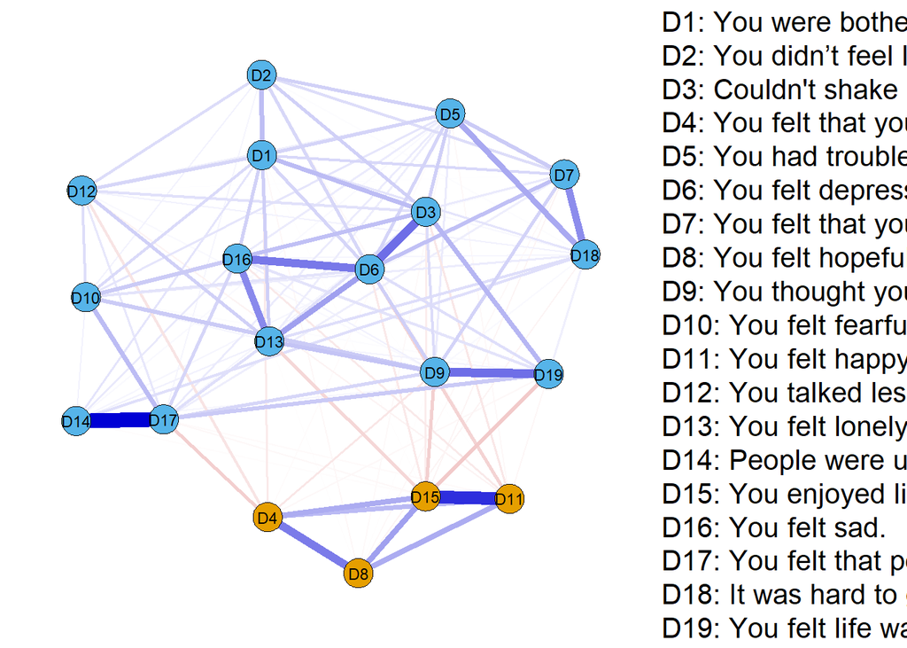

```r
#save(net1, file='net1.rdata')

netplot1 <- plot(net1, layout = "spring", vsize = 3.5,
                 border.color="black",
                 nodeNames = nameslong,
                 groups = groups,
                 legend.mode = "names",
                 label.cex = 1.7,
                 legend.cex = .65,
                 layoutOffset = c(0,0),
                 GLratio = 2.7,
                 width = 17, height = 9,
                 #filetype = "pdf", filename = "netplot",
                 plot = T)
```

Compute expected influence indices (EI) for each node. The EI of a node is the sum of the weights connected to that node. It’s a measure of the “centrality” of a node in a network. These are highly connected nodes, and thus hypothesized to be influential in the network. As depression is conceptualized here as a causal network, central nodes may be important targets for intervention.

```
## Note: z-scores are shown on x-axis rather than raw centrality indices.
```

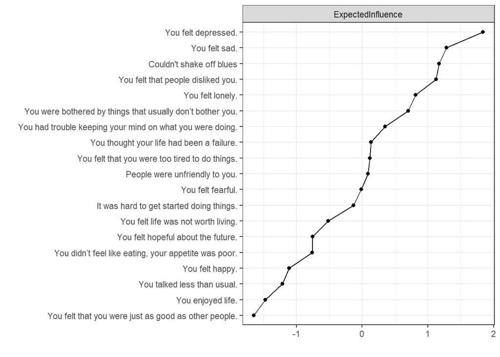

```r
ef1 <- centralityPlot(net1, include = c("ExpectedInfluence"), scale = 'z-score',
                labels = nameslong,
                orderBy = "ExpectedInfluence")
```

Run univariable logistic regressions predicting adult depression (W5) from each individual symptom (W1)

```r
mod1 <- glm(DEPR ~ D1,
            family = "binomial", data = dat_adol)
or1 <- exp(cbind(OR = coef(mod1), confint(mod1)))[2,]



mod2 <- glm(DEPR ~ D2,
            family = "binomial", data = dat_adol)
or2 <- exp(cbind(OR = coef(mod2), confint(mod2)))[2,]


mod3 <- glm(DEPR ~ D3,
            family = "binomial", data = dat_adol)
or3 <- exp(cbind(OR = coef(mod3), confint(mod3)))[2,]


mod4 <- glm(DEPR ~ D4,
            family = "binomial", data = dat_adol)
or4 <- exp(cbind(OR = coef(mod4), confint(mod4)))[2,]


mod5 <- glm(DEPR ~ D5,
            family = "binomial", data = dat_adol)
or5 <- exp(cbind(OR = coef(mod5), confint(mod5)))[2,]


mod6 <- glm(DEPR ~ D6,
            family = "binomial", data = dat_adol)
or6 <- exp(cbind(OR = coef(mod6), confint(mod6)))[2,]


mod7 <- glm(DEPR ~ D7,
            family = "binomial", data = dat_adol)
or7 <- exp(cbind(OR = coef(mod7), confint(mod7)))[2,]


mod8 <- glm(DEPR ~ D8,
            family = "binomial", data = dat_adol)
or8 <- exp(cbind(OR = coef(mod8), confint(mod8)))[2,]


mod9 <- glm(DEPR ~ D9,
            family = "binomial", data = dat_adol)
or9 <- exp(cbind(OR = coef(mod9), confint(mod9)))[2,]



mod10 <- glm(DEPR ~ D10,
            family = "binomial", data = dat_adol)
or10 <- exp(cbind(OR = coef(mod10), confint(mod10)))[2,]



mod11 <- glm(DEPR ~ D11,
            family = "binomial", data = dat_adol)
or11 <- exp(cbind(OR = coef(mod11), confint(mod11)))[2,]



mod12 <- glm(DEPR ~ D12,
            family = "binomial", data = dat_adol)
or12 <- exp(cbind(OR = coef(mod12), confint(mod12)))[2,]



mod13 <- glm(DEPR ~ D13,
            family = "binomial", data = dat_adol)
or13 <- exp(cbind(OR = coef(mod13), confint(mod13)))[2,]



mod14 <- glm(DEPR ~ D14,
            family = "binomial", data = dat_adol)
or14 <- exp(cbind(OR = coef(mod14), confint(mod14)))[2,]



mod15 <- glm(DEPR ~ D15,
            family = "binomial", data = dat_adol)
or15 <- exp(cbind(OR = coef(mod15), confint(mod15)))[2,]



mod16 <- glm(DEPR ~ D16,
            family = "binomial", data = dat_adol)
or16 <- exp(cbind(OR = coef(mod16), confint(mod16)))[2,]


mod17 <- glm(DEPR ~ D17,
            family = "binomial", data = dat_adol)
or17 <- exp(cbind(OR = coef(mod17), confint(mod17)))[2,]


mod18 <- glm(DEPR ~ D18,
            family = "binomial", data = dat_adol)
or18 <- exp(cbind(OR = coef(mod18), confint(mod18)))[2,]



mod19 <- glm(DEPR ~ D19,
             family = "binomial", data = dat_adol)
or19 <- exp(cbind(OR = coef(mod19), confint(mod19)))[2,]
```

Bind ORs to data frame with EI, node names, and symptom names

```r
or_all <- rbind(or4,or15,or12,or11,or2,or8,or9,or18,or10,or14,or7,or9,or5,or1,or13,or17,or3,or16,or6)

pvals <- c('0.057', '0.0045', '0.714', '0.45', '0.0045', '0.107', '0.155',
           '<0.001', '0.438', '0.865', '0.099', '0.155', '<0.001', '<0.001',
           '0.002', '0.169', '<0.001', '<0.001', '<0.001')


ef1.df <- as.data.frame(cbind(as.character(ef1$data$node), ef1$data$value))

colnames(ef1.df) <- c('Symptom', 'ExpectedInfluence')


results <- as.data.frame(cbind(ef1.df, or_all, pvals))
options(digits = 2)
results$ExpectedInfluence <- as.numeric(results$ExpectedInfluence)
results$OR <- as.numeric(results$OR)
results$`2.5 %` <- as.numeric(results$`2.5 %`)
results$`97.5 %` <- as.numeric(results$`97.5 %`)


kbl(results) %>%
  kable_styling(bootstrap_options = "striped", font_size = 9) %>%
   scroll_box(width = "100%")
```

|  | Symptom | ExpectedInfluence | OR | 2.5 % | 97.5 % | pvals |
| --- | --- | --- | --- | --- | --- | --- |
| or4 | You felt that you were just as good as other people. | -1.65 | 0.92 | 0.84 | 1.00 | 0.057 |
| or15 | You enjoyed life. | -1.47 | 0.86 | 0.77 | 0.95 | 0.0045 |
| or12 | You talked less than usual. | -1.21 | 0.98 | 0.86 | 1.11 | 0.714 |
| or11 | You felt happy. | -1.11 | 0.96 | 0.85 | 1.08 | 0.45 |
| or2 | You didn’t feel like eating, your appetite was poor. | -0.76 | 1.21 | 1.06 | 1.37 | 0.0045 |
| or8 | You felt hopeful about the future. | -0.76 | 0.93 | 0.84 | 1.02 | 0.107 |
| or9 | You felt life was not worth living. | -0.52 | 1.14 | 0.95 | 1.37 | 0.155 |
| or18 | It was hard to get started doing things. | -0.13 | 1.36 | 1.19 | 1.56 | <0.001 |
| or10 | You felt fearful. | -0.01 | 1.07 | 0.91 | 1.25 | 0.438 |
| or14 | People were unfriendly to you. | 0.09 | 1.01 | 0.87 | 1.17 | 0.865 |
| or7 | You felt that you were too tired to do things. | 0.12 | 1.11 | 0.98 | 1.25 | 0.099 |
| or9.1 | You thought your life had been a failure. | 0.13 | 1.14 | 0.95 | 1.37 | 0.155 |
| or5 | You had trouble keeping your mind on what you were doing. | 0.35 | 1.27 | 1.14 | 1.42 | <0.001 |
| or1 | You were bothered by things that usually don’t bother you. | 0.70 | 1.40 | 1.22 | 1.60 | <0.001 |
| or13 | You felt lonely. | 0.81 | 1.23 | 1.08 | 1.39 | 0.002 |
| or17 | You felt that people disliked you. | 1.13 | 1.10 | 0.96 | 1.26 | 0.169 |
| or3 | Couldn’t shake off blues | 1.17 | 1.37 | 1.21 | 1.56 | <0.001 |
| or16 | You felt sad. | 1.28 | 1.29 | 1.13 | 1.47 | <0.001 |
| or6 | You felt depressed. | 1.84 | 1.31 | 1.16 | 1.48 | <0.001 |

Plot association of EIs with ORs

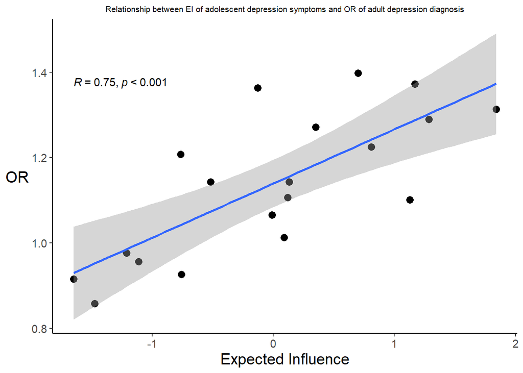

```r
ggplot(results, aes(x = ExpectedInfluence, y = OR)) +
  geom_point(size = 3, shape = 21, color = "black", fill = "black") +
  geom_smooth(method = lm) +
  stat_cor(p.accuracy = 0.001, r.accuracy = 0.01)+
  labs(y = "OR", x = "Expected Influence", title = "Relationship between EI of adolescent depression symptoms and OR of adult depression diagnosis") +
  theme_classic() + theme(plot.title = element_text(hjust = 0.5, size = 8),
                          axis.title = element_text(size = 15),
                          axis.title.y = element_text(angle = 0, vjust = 0.5),
                          axis.text = element_text(size = 11))
```

As many factors beyond depressive symtomatology and severity influences a depression diagnosis, we add potentially confounding covariates into the model and run a multiple logistic regression, yielding aORs for each depressive symptom.

Covariates include sex, race, household type (married family, non-family, other), median household income, and modal household education (no high school, high school, college).

Check missingness of covariates

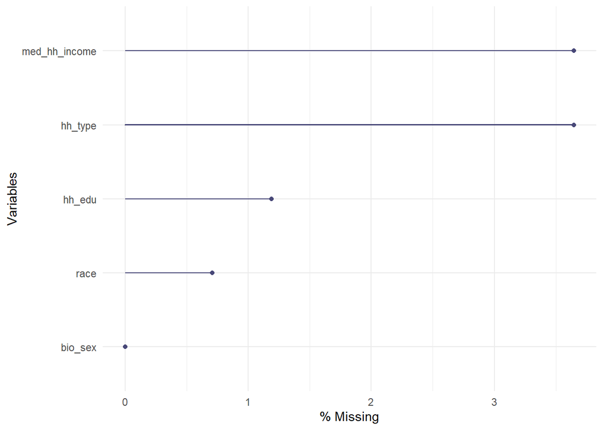

```r
library(naniar)

gg_miss_var(dat_adol %>%
  dplyr::select(bio_sex, race, hh_type, med_hh_income, hh_edu), show_pct = T)
```

Impute missing values using multiple imputation by chained equations.

```r
library(broom.mixed)
library(MCMCglmm)
library(msm)
library(tmvtnorm)
library(mice)
library(miceadds)
```

```r
predMatrix <- quickpred(dat_adol, mincor=0.10)
predMatrix[, c("ID")] <- 0


impMethod <- make.method(data = dat_adol, defaultMethod = "pmm")

impMethod[c("race")] <- "polyreg"
impMethod[c("hh_edu")] <- "polyreg"
impMethod[c("hh_type")] <- "polyreg"
impMethod[c("med_hh_income")] <- "pmm"



# dat_imp <- mice(dat_adol, method = 'pmm',
#                 predictorMatrix = predMatrix,
#                     maxit = 3,
#                     m = 3,
#                     seed = 111)


#save(dat_imp, file = "dat_imp.RData")

load('dat_imp.rdata')
```

Model a multiple logistic regression of depression diagnosis with depression and covariates as predictors. Use all imputed data sets, and combine using Rubin’s Rules.

```r
mod1.1 <- with(dat_imp, glm(DEPR ~ D1 +
                bio_sex + race + hh_type + med_hh_income + hh_edu,
            family = "binomial"))

or1.1 <- summary(pool(mod1.1), conf.int = T, exponentiate = T)
or1.1 <- cbind(OR = or1.1[2,2], '2.5%' = or1.1[2,7], '97.5%' = or1.1[2,8])




mod2.1 <- with(dat_imp, glm(DEPR ~ D2 +
                bio_sex + race + hh_type + med_hh_income + hh_edu,
            family = "binomial"))

or2.1 <- summary(pool(mod2.1), conf.int = T, exponentiate = T)
or2.1 <- cbind(OR = or2.1[2,2], '2.5%' = or2.1[2,7], '97.5%' = or2.1[2,8])



mod3.1 <- with(dat_imp, glm(DEPR ~ D3 +
                bio_sex + race + hh_type + med_hh_income + hh_edu,
            family = "binomial"))

or3.1 <- summary(pool(mod3.1), conf.int = T, exponentiate = T)
or3.1 <- cbind(OR = or3.1[2,2], '2.5%' = or3.1[2,7], '97.5%' = or3.1[2,8])



mod4.1 <- with(dat_imp, glm(DEPR ~ D4 +
                bio_sex + race + hh_type + med_hh_income + hh_edu,
            family = "binomial"))

or4.1 <- summary(pool(mod4.1), conf.int = T, exponentiate = T)
or4.1 <- cbind(OR = or4.1[2,2], '2.5%' = or4.1[2,7], '97.5%' = or4.1[2,8])



mod5.1 <- with(dat_imp, glm(DEPR ~ D5 +
                bio_sex + race + hh_type + med_hh_income + hh_edu,
            family = "binomial"))

or5.1 <- summary(pool(mod5.1), conf.int = T, exponentiate = T)
or5.1 <- cbind(OR = or5.1[2,2], '2.5%' = or5.1[2,7], '97.5%' = or5.1[2,8])



mod6.1 <- with(dat_imp, glm(DEPR ~ D6 +
                bio_sex + race + hh_type + med_hh_income + hh_edu,
            family = "binomial"))

or6.1 <- summary(pool(mod6.1), conf.int = T, exponentiate = T)
or6.1 <- cbind(OR = or6.1[2,2], '2.5%' = or6.1[2,7], '97.5%' = or6.1[2,8])




mod7.1 <- with(dat_imp, glm(DEPR ~ D7 +
                bio_sex + race + hh_type + med_hh_income + hh_edu,
            family = "binomial"))

or7.1 <- summary(pool(mod7.1), conf.int = T, exponentiate = T)
or7.1 <- cbind(OR = or7.1[2,2], '2.5%' = or7.1[2,7], '97.5%' = or7.1[2,8])




mod8.1 <- with(dat_imp, glm(DEPR ~ D8 +
                bio_sex + race + hh_type + med_hh_income + hh_edu,
            family = "binomial"))

or8.1 <- summary(pool(mod8.1), conf.int = T, exponentiate = T)
or8.1 <- cbind(OR = or8.1[2,2], '2.5%' = or8.1[2,7], '97.5%' = or8.1[2,8])




mod9.1 <- with(dat_imp, glm(DEPR ~ D9 +
                bio_sex + race + hh_type + med_hh_income + hh_edu,
            family = "binomial"))

or9.1 <- summary(pool(mod9.1), conf.int = T, exponentiate = T)
or9.1 <- cbind(OR = or9.1[2,2], '2.5%' = or9.1[2,7], '97.5%' = or9.1[2,8])




mod10.1 <- with(dat_imp, glm(DEPR ~ D10 +
                bio_sex + race + hh_type + med_hh_income + hh_edu,
            family = "binomial"))

or10.1 <- summary(pool(mod10.1), conf.int = T, exponentiate = T)
or10.1 <- cbind(OR = or10.1[2,2], '2.5%' = or10.1[2,7], '97.5%' = or10.1[2,8])




mod11.1 <- with(dat_imp, glm(DEPR ~ D11 +
                bio_sex + race + hh_type + med_hh_income + hh_edu,
            family = "binomial"))

or11.1 <- summary(pool(mod11.1), conf.int = T, exponentiate = T)
or11.1 <- cbind(OR = or11.1[2,2], '2.5%' = or11.1[2,7], '97.5%' = or11.1[2,8])





mod12.1 <- with(dat_imp, glm(DEPR ~ D12 +
                bio_sex + race + hh_type + med_hh_income + hh_edu,
            family = "binomial"))

or12.1 <- summary(pool(mod12.1), conf.int = T, exponentiate = T)
or12.1 <- cbind(OR = or12.1[2,2], '2.5%' = or12.1[2,7], '97.5%' = or12.1[2,8])





mod13.1 <- with(dat_imp, glm(DEPR ~ D13 +
                bio_sex + race + hh_type + med_hh_income + hh_edu,
            family = "binomial"))

or13.1 <- summary(pool(mod13.1), conf.int = T, exponentiate = T)
or13.1 <- cbind(OR = or13.1[2,2], '2.5%' = or13.1[2,7], '97.5%' = or13.1[2,8])





mod14.1 <- with(dat_imp, glm(DEPR ~ D14 +
                bio_sex + race + hh_type + med_hh_income + hh_edu,
            family = "binomial"))

or14.1 <- summary(pool(mod14.1), conf.int = T, exponentiate = T)
or14.1 <- cbind(OR = or14.1[2,2], '2.5%' = or14.1[2,7], '97.5%' = or14.1[2,8])





mod15.1 <- with(dat_imp, glm(DEPR ~ D15 +
                bio_sex + race + hh_type + med_hh_income + hh_edu,
            family = "binomial"))

or15.1 <- summary(pool(mod15.1), conf.int = T, exponentiate = T)
or15.1 <- cbind(OR = or15.1[2,2], '2.5%' = or15.1[2,7], '97.5%' = or15.1[2,8])





mod16.1 <- with(dat_imp, glm(DEPR ~ D16 +
                bio_sex + race + hh_type + med_hh_income + hh_edu,
            family = "binomial"))

or16.1 <- summary(pool(mod16.1), conf.int = T, exponentiate = T)
or16.1 <- cbind(OR = or16.1[2,2], '2.5%' = or16.1[2,7], '97.5%' = or16.1[2,8])





mod17.1 <- with(dat_imp, glm(DEPR ~ D17 +
                bio_sex + race + hh_type + med_hh_income + hh_edu,
            family = "binomial"))

or17.1 <- summary(pool(mod17.1), conf.int = T, exponentiate = T)
or17.1 <- cbind(OR = or17.1[2,2], '2.5%' = or17.1[2,7], '97.5%' = or17.1[2,8])





mod18.1 <- with(dat_imp, glm(DEPR ~ D18 +
                bio_sex + race + hh_type + med_hh_income + hh_edu,
            family = "binomial"))

or18.1 <- summary(pool(mod1.1), conf.int = T, exponentiate = T)
or18.1 <- cbind(OR = or18.1[2,2], '2.5%' = or18.1[2,7], '97.5%' = or18.1[2,8])






mod19.1 <- with(dat_imp, glm(DEPR ~ D19 +
                bio_sex + race + hh_type + med_hh_income + hh_edu,
            family = "binomial"))

or19.1 <- summary(pool(mod19.1), conf.int = T, exponentiate = T)
or19.1 <- cbind(OR = or19.1[2,2], '2.5%' = or19.1[2,7], '97.5%' = or19.1[2,8])
```

Consolidate results into a table

```r
or_all.1 <- rbind(or4.1,or15.1,or12.1,or11.1,or2.1,or8.1,or9.1,or18.1,or10.1,or14.1,or7.1,or9.1,or5.1,or1.1,or13.1,or17.1,or3.1,or16.1,or6.1)

pvals <- c('<0.001', '0.086', '<0.001', '0.308', '<0.001', '<0.001', '0.180',
           '0.090', '0.136', '0.639', '0.248', '0.830', '0.018', '0.837',
           '0.027', '0.003', '0.201', '<0.001', '0.774')


ef1.df <- as.data.frame(cbind(as.character(ef1$data$node), ef1$data$value))

colnames(ef1.df) <- c('Symptom', 'ExpectedInfluence')


results.1 <- as.data.frame(cbind(ef1.df, or_all.1, pvals))
options(digits = 2)
results.1$ExpectedInfluence <- as.numeric(results.1$ExpectedInfluence)
results.1$OR <- as.numeric(results.1$OR)
results.1$`2.5%` <- as.numeric(results.1$`2.5%`)
results.1$`97.5%` <- as.numeric(results.1$`97.5%`)


kbl(results.1) %>%
  kable_styling(bootstrap_options = "striped", font_size = 9) %>%
   scroll_box(width = "100%")
```

| Symptom | ExpectedInfluence | OR | 2.5% | 97.5% | pvals |
| --- | --- | --- | --- | --- | --- |
| You felt that you were just as good as other people. | -1.65 | 0.95 | 0.87 | 1.05 | <0.001 |
| You enjoyed life. | -1.47 | 0.88 | 0.79 | 0.99 | 0.086 |
| You talked less than usual. | -1.21 | 1.01 | 0.89 | 1.15 | <0.001 |
| You felt happy. | -1.11 | 0.93 | 0.83 | 1.05 | 0.308 |
| You didn’t feel like eating, your appetite was poor. | -0.76 | 1.12 | 0.98 | 1.29 | <0.001 |
| You felt hopeful about the future. | -0.76 | 0.92 | 0.84 | 1.01 | <0.001 |
| You felt life was not worth living. | -0.52 | 1.16 | 0.96 | 1.40 | 0.180 |
| It was hard to get started doing things. | -0.13 | 1.33 | 1.15 | 1.53 | 0.090 |
| You felt fearful. | -0.01 | 1.04 | 0.88 | 1.22 | 0.136 |
| People were unfriendly to you. | 0.09 | 1.02 | 0.87 | 1.18 | 0.639 |
| You felt that you were too tired to do things. | 0.12 | 1.09 | 0.96 | 1.23 | 0.248 |
| You thought your life had been a failure. | 0.13 | 1.16 | 0.96 | 1.40 | 0.830 |
| You had trouble keeping your mind on what you were doing. | 0.35 | 1.25 | 1.12 | 1.40 | 0.018 |
| You were bothered by things that usually don’t bother you. | 0.70 | 1.33 | 1.15 | 1.53 | 0.837 |
| You felt lonely. | 0.81 | 1.17 | 1.03 | 1.34 | 0.027 |
| You felt that people disliked you. | 1.13 | 1.10 | 0.95 | 1.26 | 0.003 |
| Couldn’t shake off blues | 1.17 | 1.30 | 1.14 | 1.49 | 0.201 |
| You felt sad. | 1.28 | 1.23 | 1.07 | 1.41 | <0.001 |
| You felt depressed. | 1.84 | 1.24 | 1.10 | 1.41 | 0.774 |

```r
#save(results.1, file='results1.rdata')
```

Plot relationship between EIs and aORs of depression symptoms

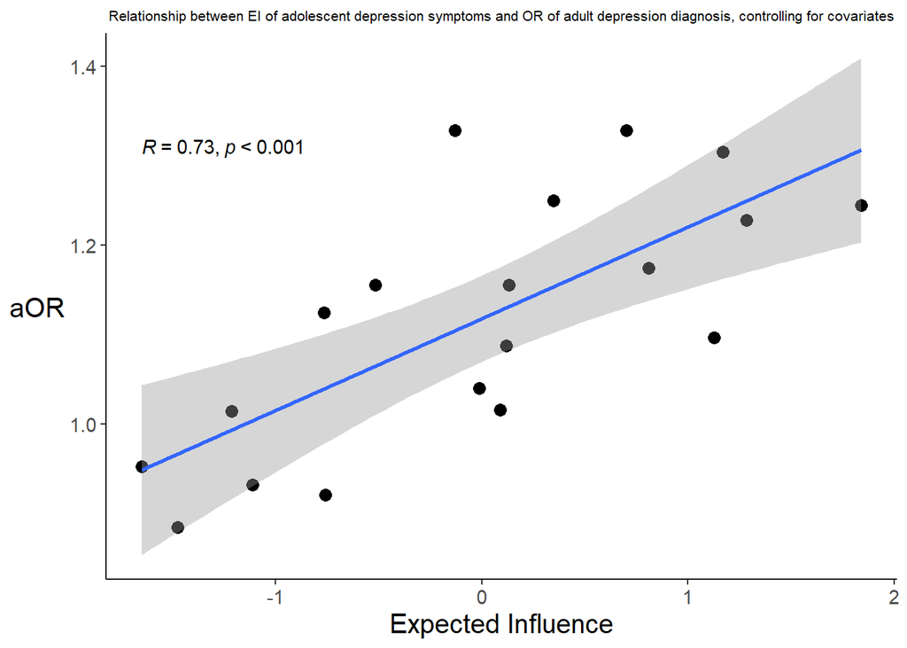

```r
ggplot(results.1, aes(x = ExpectedInfluence, y = OR)) +
  geom_point(size = 3, shape = 21, color = "black", fill = "black") +
  geom_smooth(method = lm) +
  stat_cor(p.accuracy = 0.001, r.accuracy = 0.01)+
  labs(y = "aOR", x = "Expected Influence", title = "Relationship between EI of adolescent depression symptoms and OR of adult depression diagnosis, controlling for covariates") +
  theme_classic() + theme(plot.title = element_text(hjust = 0.5, size = 8),
                          axis.title = element_text(size = 15),
                          axis.title.y = element_text(angle = 0, vjust = 0.5),
                          axis.text = element_text(size = 11))
```

Node centrality of depressive symptoms during adolescence, quantified using the expected influence index, is moderately predictive of an adult diagnosis of depression, with correlations of EI and ORs of 0.73-0.75.

Limitations include the absence of core depression symptoms (e.g., insomnia, anhedonia) included in the CESD, and unobserved confounders of the relationship between depression diagnosis and individual symptoms.